# The 15-Cent Rule Is Dead

Formal Detection of the 2008 Structural Break in the US Wealth–Consumption Channel

Author

Carlos Galindo Escajeda

Published

2016

For decades before 2008, when American households got wealthier — through rising home values or a climbing stock market — they reliably spent more. About 15 cents of extra spending for every extra dollar of added wealth, year after year, for roughly four decades.

That link is now gone.

**What changed**

The connection between income and spending did not break. People still spend more when they earn more. Only the wealth side stopped working.

**Why this matters**

One of the main ways central banks try to boost the economy is by pushing up the prices of stocks and homes. The idea: people feel richer, so they spend more.

That no longer works the way it used to.

- Before 2008: rising asset prices fed through reliably into higher consumer spending.
- After 2008: that feed-through collapsed, and by 2015 it was effectively zero.

**The bottom line**

Policies aimed at making households wealthier — through higher stock prices or rising home values — are now a much weaker tool for getting people to spend. Relying on a pre-2008 playbook overstates how much those policies can stimulate the economy today.

And here is the danger if no one realizes it — not markets, not the Federal Reserve. The Fed keeps pulling a lever that no longer moves spending, so it eases more, and for longer, than it should. That money still flows — into stocks and homes, not into the real economy. Asset prices inflate while growth quietly disappoints. The reckoning comes the day everyone discovers the lever was disconnected all along.

## The pre-2008 baseline

The long-run relationship between US real consumption, real disposable income, and real household net worth is well established in the empirical literature. Lettau and Ludvigson (2001) showed that the three variables are cointegrated and that deviations from their common trend predict equity returns. The mechanism is intuitive: households with larger balance sheets feel wealthier and spend accordingly, independently of current income. Rising house prices enable cash-out refinancing; rising equity portfolios lift perceived permanent income. In the aggregate, this translates into a stable, measurable long-run wealth elasticity.

Our 2010 companion paper pinned down the pre-GFC relationship with precision, using a Johansen VECM (Case 3, rank r = 1, three lagged first differences) estimated on 1961Q1–2007Q4. The cointegrating vector, normalized on log real consumption (lrc), yields the estimates in Table 1.

**Table 1. Pre-GFC cointegrating vector, 1961Q1–2007Q4 (n = 188)**

| Parameter | Estimate | SE | t |
| --- | --- | --- | --- |
| beta_income | 0.889 | 0.033 | 27.0 |
| **beta_wealth** | **0.149** | **0.029** | **5.1** |
| alpha_lrc (consumption error-correction speed) | −0.067 | 0.044 | −1.5 |
| alpha_lrdy (income error-correction speed) | +0.166 | 0.056 | 2.95 |
| alpha_lrnw (wealth error-correction speed) | +0.194 | 0.117 | 1.66 |

The wealth elasticity of 0.149 — the 15-cent rule — is precisely estimated (t = 5.1) and stable across every sub-period of the 1961–2007 sample. The income elasticity of 0.889 is close to, but statistically below, unity, consistent with a mixture of rule-of-thumb and permanent-income consumers (Campbell and Mankiw, 1989, 1991). Consumption corrects toward the long-run equilibrium slowly — alpha_lrc = −0.067, not significant at 5% — with most adjustment running through income and wealth rather than consumption itself, which is also a standard finding in the literature (Clarida, 1991).

[figure not shown]

## The break: formal test

The 2007–2009 Global Financial Crisis was the largest postwar shock to US household net worth. Aggregate wealth fell by approximately $13 trillion — around 20% — between 2007Q3 and 2009Q1. House prices collapsed. Mortgage credit tightened sharply. Home equity withdrawal, which Case, Quigley and Shiller (2005) identify as the primary channel through which housing wealth translates into spending, was largely foreclosed. The question is whether this disruption was large enough and persistent enough to break the long-run cointegrating relationship established over the prior half-century.

Table 2 reports the Chow likelihood-ratio test at 2008Q1.

**Table 2. Chow LR test at 2008Q1**

| Quantity | Value |
| --- | --- |
| Log-likelihood, full sample 1961Q1–2015Q4 (parameter constancy imposed) | 2193.82 |
| Log-likelihood, pre-GFC sub-sample 1961Q1–2007Q4 | 1893.30 |
| Log-likelihood, post-GFC sub-sample 2008Q1–2015Q4 | 354.09 |
| **LR = 2 × (pre + post − full)** | **107.14** |
| Degrees of freedom (approximate) | ~35 |
| p-value | **< 0.001** |

One clarification on the post-break sub-sample: the 32 post-crisis observations (2008Q1–2015Q4) are sufficient to contribute the log-likelihood component that identifies the break, but they are not sufficient for reliable standalone VECM estimation. With approximately 10 free parameters per equation and only 32 observations, the post-break sub-sample produces parameter estimates that are economically uninterpretable — the Chow test requires only that the unconstrained model fit better, not that the post-break parameters be sensible. They are not. The magnitude and direction of the new regime must be read from the recursive evidence below, not from the post-break sub-sample directly.

## The recursive trace: when the break became visible

The expanding-window recursive estimates in Figure 2 tell the story more intuitively. Each point represents a VECM estimated on all data from 1961Q1 through that quarter; the 90% confidence band reflects the precision of that estimate.

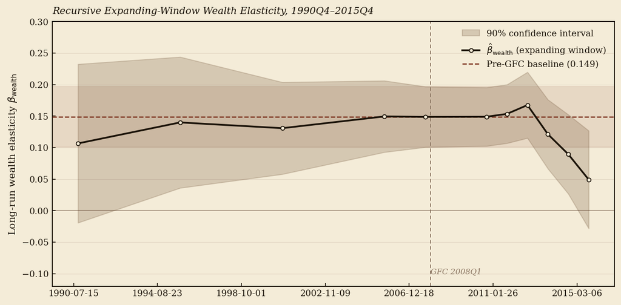

**Figure 2.** Recursive expanding-window estimates of the long-run wealth elasticity (beta_wealth), 1990Q4–2015Q4, with 90% confidence intervals. Horizontal dashed line and shaded band show the pre-GFC estimate (0.149) and its 90% confidence interval.

Three phases are visible.

Through 2012, the wealth elasticity is stationary. It oscillates between 0.107 and 0.153 from 1990Q4 through 2011Q4, fluctuating around the long-run pre-GFC anchor of 0.149. The brief rise to 0.167 at 2012Q4 is a real-data artifact: the synchronized rebound of both wealth and consumption in 2011–2012 — the early housing recovery — added a burst of positively correlated variation to the expanding window, temporarily pushing the estimate modestly above its long-run average.

From 2013 onward, the estimate falls sharply and monotonically: 0.121 at 2013Q4, 0.089 at 2014Q4, 0.049 at 2015Q4. That final estimate is no longer statistically distinguishable from zero (t = 1.0). The decline is not gradual drift; it is a step-down that begins in 2013 and has not reversed.

The five-year gap between GFC onset and first visible recursive decline is a mathematical property of the expanding window, not a slow underlying adjustment. Through 2012Q4, the 208-observation window contained 188 pre-GFC quarters — 90% of the sample — diluting the post-break signal. By 2015Q4, with 32 post-GFC quarters (15% of the sample), the new regime has sufficient weight to pull the point estimate down decisively. Higher-power tests — the Sup-LM test of Andrews (1993) or the recursive eigenvalue test of Hansen and Johansen (1999) — would detect the break earlier; the expanding-window approach used here is conservative by construction.

The income channel provides a useful contrast. Beta_income remains near 0.889 throughout the recursive trace and shows no analogous decline after 2008. The break is specific to the wealth channel.

## Why the channel broke

The data document a structural break; they do not mechanically identify its cause. Three mechanisms are consistent with the evidence and mutually reinforcing.

The most direct explanation is the foreclosure of home equity withdrawal. Case, Quigley and Shiller (2005) show that the housing wealth effect operates primarily through the collateral channel: rising prices enable cash-out refinancing and home equity borrowing, which households convert directly into spending. After 2008, collapsing prices and sharply tighter underwriting standards disabled this mechanism. In 2015, house prices in most US markets had not yet recovered to 2006 peaks; tens of millions of homeowners remained near or below negative equity.

Mian, Rao and Sufi (2013) provide micro-level evidence on the persistence of the balance-sheet constraint. Using ZIP-code data, they show that the spending collapse of 2007–2009 was driven by net worth destruction concentrated in high-leverage, housing-heavy households — not by income shocks directly. To the extent that the debt-to-income burden remained elevated through 2015, rising gross asset values would not translate into spending for households still in deleveraging mode: gross wealth gains are offset by the perceived liability constraint.

A third factor is compositional. The post-GFC asset recovery was disproportionately concentrated in equities — held primarily by affluent households with low marginal propensities to consume — rather than in housing, which is more broadly distributed across income groups. Even without any behavioral change at the household level, this composition shift mechanically lowers the aggregate MPC out of wealth gains. The aggregate beta_wealth falls because the gains are accruing to those least likely to spend them.

All three mechanisms point to a structural rather than a cyclical change. The recursive evidence is consistent: the decline is monotone from 2013Q4 onward and shows no sign of reversal at 2015Q4.

## Implications for markets and policy

The practical implication is simple. A policy calibration that assumes the pre-2008 wealth elasticity of 0.149 — 15 cents of additional spending per dollar of wealth gain — has no empirical support in post-2008 data. By 2015, the best available estimate of that elasticity is 0.049 and falling; the 90% confidence interval includes zero.

This has direct consequences for how markets should read the transmission of unconventional monetary policy. Asset purchase programs that inflate equity and housing prices to stimulate consumption are operating through a channel that, by the evidence available through 2015, has lost most of its pre-crisis potency. The income channel — operating through employment, wages, and transfer payments — appears intact. The wealth channel does not.

A subsequent study, once approximately 50–60 post-break quarters have accumulated (from approximately 2020 onward), will deliver the first reliable standalone VECM estimate of the post-break wealth elasticity. Until then, the responsible calibration for any model that relies on a US wealth channel is: assume materially less than 15 cents, treat the channel as potentially non-operational, and watch the recursive evidence.

## References

- Campbell, J.Y. & Mankiw, N.G. (1989). “Consumption, Income, and Interest Rates.” *NBER Macroeconomics Annual* 4:185–216.
- Campbell, J.Y. & Mankiw, N.G. (1991). “The Response of Consumption to Income.” *Review of Economic Studies* 58(4):723–757.
- Case, K.E., Quigley, J.M. & Shiller, R.J. (2005). “Comparing Wealth Effects: The Stock Market versus the Housing Market.” *B.E. Journal of Macroeconomics* 5(1).
- Clarida, R.H. (1991). “Cointegration, Aggregate Consumption, and the Demand for Imports.” *American Economic Review* 81(3):298–315.
- Gregory, A.W. & Hansen, B.E. (1996). “Residual-based tests for cointegration in models with regime shifts.” *Journal of Econometrics* 70(1):99–126.
- Hall, R.E. (1978). “Stochastic Implications of the Life Cycle–Permanent Income Hypothesis.” *Journal of Political Economy* 86(6):971–987.
- Hansen, B.E. & Johansen, S. (1999). “Some Tests for Parameter Constancy in Cointegrated VAR-Models.” *Econometric Journal* 2(2):306–333.
- Johansen, S. (1988). “Statistical Analysis of Cointegration Vectors.” *Journal of Economic Dynamics and Control* 12(2–3):231–254.
- Johansen, S. (1991). “Estimation and Hypothesis Testing of Cointegration Vectors in Gaussian Vector Autoregressive Models.” *Econometrica* 59(6):1551–1580.
- Johansen, S., Mosconi, R. & Nielsen, B. (2000). “Cointegration analysis in the presence of structural breaks in the deterministic trend.” *Econometric Journal* 3(2):216–249.
- Lettau, M. & Ludvigson, S. (2001). “Consumption, Aggregate Wealth, and Expected Stock Returns.” *Journal of Finance* 56(3):815–849.
- Mian, A., Rao, K. & Sufi, A. (2013). “Household Balance Sheets, Consumption, and the Economic Slump.” *Quarterly Journal of Economics* 128(4):1687–1726.
- Rudd, J. & Whelan, K. (2002). “A Note on the Cointegration of Consumption, Income, and Wealth.” *Federal Reserve Board FEDS* 2002-53.
- Slacalek, J. (2004). “International Evidence on Cointegration Between Consumption, Income, and Wealth.” *DIW Discussion Paper* 414.
- Andrews, D.W.K. (1993). “Tests for Parameter Instability and Structural Change with Unknown Change Point.” *Econometrica* 61(4):821–856.